# GeoMX Dataset Tutorial

Igor Cervenka

2024-02-01

# Loading libraries

Load required GeoMx and nanostring packages.

```r
library(NanoStringNCTools)
library(GeomxTools)
library(GeoMxWorkflows)
```

Load other useful packages.

```r
library(knitr)
library(scales)
library(stringr)
library(ggplot2)
library(dplyr)
```

# Loading data

Set path to example data directory that comes with the package.

```r
datadir <- system.file("extdata", "WTA_NGS_Example", package = "GeoMxWorkflows")
```

Locate dcc, pck and annotation files.

```r
DCCFiles <- dir(file.path(datadir, "dccs"),
  pattern = ".dcc$",
  full.names = TRUE, recursive = TRUE
)

PKCFiles <- unzip(zipfile = dir(file.path(datadir, "pkcs"),
  pattern = ".zip$",
  full.names = TRUE, recursive = TRUE
))

SampleAnnotationFile <- dir(file.path(datadir, "annotation"),
  pattern = ".xlsx$",
  full.names = TRUE, recursive = TRUE
)
```

These variables only store file paths, not actual data.

```r
SampleAnnotationFile
```

```
## [1] "/Library/Frameworks/R.framework/Versions/4.2/Resources/library/GeoMxWorkflows/extdata/WTA_NGS_Example/annotation/kidney_AOI_Annotations_all_vignette.xlsx"
```

## Create Nanostring dataset

```r
demoData <- readNanoStringGeoMxSet(
  dccFiles = DCCFiles,
  pkcFiles = PKCFiles,
  phenoDataFile = SampleAnnotationFile,
  phenoDataSheet = "Template",
  phenoDataDccColName = "Sample_ID",
  protocolDataColNames = c("aoi", "roi"),
  experimentDataColNames = c("panel")
)
```

## Important Notes

# Viewing and interrogating GeoMx data set

GeoMx dataset is based on older `ExpressionSet` objects originally developed to store microarray data, and have many similar functions as those described on [Bioconductor](https://www.bioconductor.org/packages/release/bioc/vignettes/Biobase/inst/doc/ExpressionSetIntroduction.pdf)

## GeoMx dataset structure

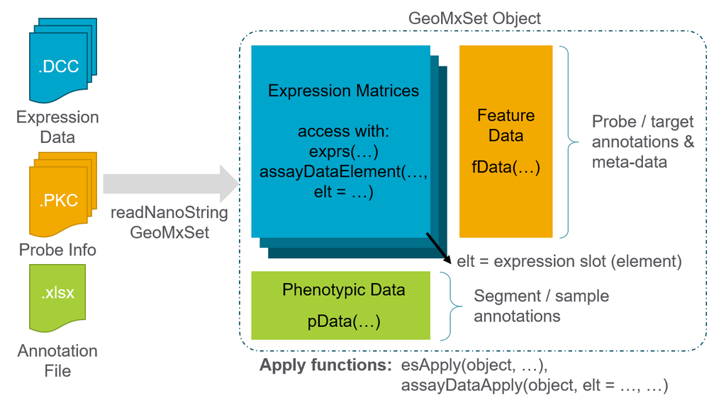

GeoMx dataset overview

Data within GeoMx dataset are internally stored in slots, accessed by operator `@`. You can find which slots are available by `slotNames` command

```r
slotNames(demoData)
```

```
##  [1] "dimLabels"         "signatures"        "design"
##  [4] "featureType"       "analyte"           "experimentData"
##  [7] "assayData"         "phenoData"         "featureData"
## [10] "annotation"        "protocolData"      ".__classVersion__"
```

```r
demoData@protocolData
```

```
## An object of class 'AnnotatedDataFrame'
##   sampleNames: DSP-1001250007851-H-A02.dcc DSP-1001250007851-H-A03.dcc
##     ... DSP-1002510007866-C-H12.dcc (235 total)
##   varLabels: FileVersion SoftwareVersion ... NTC (18 total)
##   varMetadata: labelDescription
```

Slots will carry different information related to the dataset, such as probe metadata, sample metadata, QC information and actual measurments

- `dimLabels` - labels for rows and columns of dataset, corresponds to feature IDs for rows and sample IDs for columns
- `design` - formula for design
- `featureType` - feature type indicator whether this is probe level or target level (target aggregation was done)
- `analyte` - type of analyte assayed (RNA in `demoData`)
- `experimentData` - stores structured information about the experiment
- `assayData` - stores the expression values
- `phenoData` - stores annotation data about the samples. You can add these as columns in the annotation file
- `featureData` - stores information about the targets or probes for the panel used
- `annotation` - stores the name of the PKC data
- `protocolData` - stores information about the assay run

## GeoMx dataset access

Several access functions are available for GeoMx dataset. Short intruction to R indexing can be found [here](https://cran.r-project.org/doc/manuals/R-lang.html#Indexing)

Using [ selector directly on the NanoStringGeoMx object will select or subset the probes in case of rows and SampleIDs in case of columns on ALL relevant slots

```r
demoData[1:5, 1:10]
```

```
## NanoStringGeoMxSet (storageMode: lockedEnvironment)
## assayData: 5 features, 10 samples
##   element names: exprs
## protocolData
##   sampleNames: DSP-1001250007851-H-A02.dcc DSP-1001250007851-H-A03.dcc
##     ... DSP-1001250007851-H-A11.dcc (10 total)
##   varLabels: FileVersion SoftwareVersion ... NTC (18 total)
##   varMetadata: labelDescription
## phenoData
##   sampleNames: DSP-1001250007851-H-A02.dcc DSP-1001250007851-H-A03.dcc
##     ... DSP-1001250007851-H-A11.dcc (10 total)
##   varLabels: slide name class ... nuclei (7 total)
##   varMetadata: labelDescription
## featureData
##   featureNames: RTS0020877 RTS0020878 ... RTS0020881 (5 total)
##   fvarLabels: RTS_ID TargetName ... Negative (8 total)
##   fvarMetadata: labelDescription
## experimentData: use 'experimentData(object)'
## Annotation: Hsa_WTA_v1.0.pkc
## signature: none
## feature: Probe
## analyte: RNA
```

Returns name of files for individual sequenced areas (which also correspond to sample IDs)

```r
colnames(demoData)[1:5]
```

```
## [1] "DSP-1001250007851-H-A02.dcc" "DSP-1001250007851-H-A03.dcc"
## [3] "DSP-1001250007851-H-A04.dcc" "DSP-1001250007851-H-A05.dcc"
## [5] "DSP-1001250007851-H-A06.dcc"
```

Returns the IDs of probes

```r
rownames(demoData)[1:5]
```

```
## [1] "RTS0020877" "RTS0020878" "RTS0020879" "RTS0020880" "RTS0020881"
```

### Assay data

Contains matrices connected to measured reads for each sample and probe. It is stored in the GeoMx dataset as [environment](https://adv-r.hadley.nz/environments.html)

```r
assayData(demoData)
```

```
## <environment: 0x7f96a4ae8900>
```

The easiest way to extract the contents of environment is to coerce it to list.

```r
names(as.list(assayData(demoData)))
```

```
## [1] "exprs"
```

Initially this environment will have a matrix of raw reads in a variable called `exprs`. Later, after data processing or normalization, additonal matrices with specific names will be added. To access the `exprs` variable in assay data, one can use `exprs` function directly on GeoMx object.

```r
exprs(demoData)[1:3, 1:3] # accesses the data slot in the environment
```

```
##            DSP-1001250007851-H-A02.dcc DSP-1001250007851-H-A03.dcc
## RTS0020877                         485                         262
## RTS0020878                          15                          18
## RTS0020879                          31                          15
##            DSP-1001250007851-H-A04.dcc
## RTS0020877                         225
## RTS0020878                           5
## RTS0020879                          15
```

```r
# or equivalently
as.list(assayData(demoData))$exprs[1:3, 1:3]
```

```
##            DSP-1001250007851-H-A02.dcc DSP-1001250007851-H-A03.dcc
## RTS0020877                         485                         262
## RTS0020878                          15                          18
## RTS0020879                          31                          15
##            DSP-1001250007851-H-A04.dcc
## RTS0020877                         225
## RTS0020878                           5
## RTS0020879                          15
```

GeoMx calls the variables/matrices in the `assayData` enviroment elements and you can additionally access them by `assayDataElement` function, where the second function argument is the element to return.

```r
assayDataElement(demoData, "exprs")[1:3, 1:3]
```

```
##            DSP-1001250007851-H-A02.dcc DSP-1001250007851-H-A03.dcc
## RTS0020877                         485                         262
## RTS0020878                          15                          18
## RTS0020879                          31                          15
##            DSP-1001250007851-H-A04.dcc
## RTS0020877                         225
## RTS0020878                           5
## RTS0020879                          15
```

### Phenotypic data

Contains phenotypical info and metadata such as user designations of experimental groups, tissues or segments that samples belong to. Stored as [Annotated Data Frame](https://www.rdocumentation.org/packages/Biobase/versions/2.32.0/topics/AnnotatedDataFrame).

```r
phenoData(demoData)
```

```
## An object of class 'AnnotatedDataFrame'
##   sampleNames: DSP-1001250007851-H-A02.dcc DSP-1001250007851-H-A03.dcc
##     ... DSP-1002510007866-C-H12.dcc (235 total)
##   varLabels: slide name class ... nuclei (7 total)
##   varMetadata: labelDescription
```

Contains both the actual data and metadata. Data is present in `@data` slot and metadata descriptions in `@varMetadata` slot.

```r
head(phenoData(demoData)@data)
```

```
##                             slide name class           segment     area
## DSP-1001250007851-H-A02.dcc   disease3   DKD Geometric Segment 31797.59
## DSP-1001250007851-H-A03.dcc   disease3   DKD Geometric Segment 16920.10
## DSP-1001250007851-H-A04.dcc   disease3   DKD Geometric Segment 14312.33
## DSP-1001250007851-H-A05.dcc   disease3   DKD Geometric Segment 20032.84
## DSP-1001250007851-H-A06.dcc   disease3   DKD Geometric Segment 27583.26
## DSP-1001250007851-H-A07.dcc   disease3   DKD Geometric Segment 18164.84
##                                 region pathology nuclei
## DSP-1001250007851-H-A02.dcc glomerulus  abnormal    202
## DSP-1001250007851-H-A03.dcc glomerulus  abnormal    102
## DSP-1001250007851-H-A04.dcc glomerulus  abnormal     98
## DSP-1001250007851-H-A05.dcc glomerulus  abnormal    143
## DSP-1001250007851-H-A06.dcc glomerulus  abnormal    195
## DSP-1001250007851-H-A07.dcc glomerulus  abnormal     97
```

Package also offers a shorthand function `pData` to directly extract the phenotypical data from GeoMx dataset and return is as regular data frame.

```r
head(pData(demoData))
```

```
##                             slide name class           segment     area
## DSP-1001250007851-H-A02.dcc   disease3   DKD Geometric Segment 31797.59
## DSP-1001250007851-H-A03.dcc   disease3   DKD Geometric Segment 16920.10
## DSP-1001250007851-H-A04.dcc   disease3   DKD Geometric Segment 14312.33
## DSP-1001250007851-H-A05.dcc   disease3   DKD Geometric Segment 20032.84
## DSP-1001250007851-H-A06.dcc   disease3   DKD Geometric Segment 27583.26
## DSP-1001250007851-H-A07.dcc   disease3   DKD Geometric Segment 18164.84
##                                 region pathology nuclei
## DSP-1001250007851-H-A02.dcc glomerulus  abnormal    202
## DSP-1001250007851-H-A03.dcc glomerulus  abnormal    102
## DSP-1001250007851-H-A04.dcc glomerulus  abnormal     98
## DSP-1001250007851-H-A05.dcc glomerulus  abnormal    143
## DSP-1001250007851-H-A06.dcc glomerulus  abnormal    195
## DSP-1001250007851-H-A07.dcc glomerulus  abnormal     97
```

You can use `[[` selector with metadata label to return only one column of phenotypical data.

```r
head(phenoData(demoData)[["slide name"]])
```

```
## [1] "disease3" "disease3" "disease3" "disease3" "disease3" "disease3"
```

**NOTES:**

- some of the variables are stored in `pData` as a list or nested data frame, so the name of the metadata labels might be different than the name of the columns returned
- because of this, more columns can be returned as well

The same way the package offers shorthand function `varMetadata` to extract directly the dataframe with metadata and their descriptions

```r
head(varMetadata(demoData)) # is equivalent to head(phenoData(demoData)@varMetadata)
```

```
##            labelDescription
## slide name             <NA>
## class                  <NA>
## segment                <NA>
## area                   <NA>
## region                 <NA>
## pathology              <NA>
```

Or you can use `varLabels` function if you only want the metadata as a character vector:

```r
varLabels(demoData)
```

```
## [1] "slide name" "class"      "segment"    "area"       "region"
## [6] "pathology"  "nuclei"
```

### Feature data

Annotated data frame with all feature variable values and variable meta-data. In this case features refer to the probes.

```r
head(featureData(demoData))
```

```
## An object of class 'AnnotatedDataFrame'
##   featureNames: RTS0020877 RTS0020878 ... RTS0020882 (6 total)
##   varLabels: RTS_ID TargetName ... Negative (8 total)
##   varMetadata: labelDescription
```

If you just want regular data frame with features and associated data you can use `fData` shorthand function.

```r
head(fData(demoData))
```

```
##                RTS_ID TargetName       Module  CodeClass ProbeID GeneID
## RTS0020877 RTS0020877        A2M Hsa_WTA_v1.0 Endogenous   35614      2
## RTS0020878 RTS0020878       NAT2 Hsa_WTA_v1.0 Endogenous   35615     10
## RTS0020879 RTS0020879      ACADM Hsa_WTA_v1.0 Endogenous   35616     34
## RTS0020880 RTS0020880      ACADS Hsa_WTA_v1.0 Endogenous   35617     35
## RTS0020881 RTS0020881      ACAT1 Hsa_WTA_v1.0 Endogenous   35618     38
## RTS0020882 RTS0020882     ACVRL1 Hsa_WTA_v1.0 Endogenous   35619     94
##            SystematicName Negative
## RTS0020877            A2M    FALSE
## RTS0020878           NAT2    FALSE
## RTS0020879          ACADM    FALSE
## RTS0020880          ACADS    FALSE
## RTS0020881          ACAT1    FALSE
## RTS0020882         ACVRL1    FALSE
```

Or alternatively use `pData` function on the annotated data frame, which will also return the `@data` slot

```r
head(pData(featureData(demoData))) # equivalent to the previous
```

```
##                RTS_ID TargetName       Module  CodeClass ProbeID GeneID
## RTS0020877 RTS0020877        A2M Hsa_WTA_v1.0 Endogenous   35614      2
## RTS0020878 RTS0020878       NAT2 Hsa_WTA_v1.0 Endogenous   35615     10
## RTS0020879 RTS0020879      ACADM Hsa_WTA_v1.0 Endogenous   35616     34
## RTS0020880 RTS0020880      ACADS Hsa_WTA_v1.0 Endogenous   35617     35
## RTS0020881 RTS0020881      ACAT1 Hsa_WTA_v1.0 Endogenous   35618     38
## RTS0020882 RTS0020882     ACVRL1 Hsa_WTA_v1.0 Endogenous   35619     94
##            SystematicName Negative
## RTS0020877            A2M    FALSE
## RTS0020878           NAT2    FALSE
## RTS0020879          ACADM    FALSE
## RTS0020880          ACADS    FALSE
## RTS0020881          ACAT1    FALSE
## RTS0020882         ACVRL1    FALSE
```

Similar to phenotypic data, package offers `fvarMetadata` function to access feature metadata with descriptions.

```r
fvarMetadata(demoData) # equivalent to varMetadata(featureData(demoData))
```

```
##                labelDescription
## RTS_ID                     <NA>
## TargetName                 <NA>
## Module                     <NA>
## CodeClass                  <NA>
## ProbeID                    <NA>
## GeneID                     <NA>
## SystematicName             <NA>
## Negative                   <NA>
```

And analogously to only return available metadata as character vector one can use `fvarLabels`

```r
fvarLabels(demoData) # equivalent to varLabels(featureData(demoData))
```

```
## [1] "RTS_ID"         "TargetName"     "Module"         "CodeClass"
## [5] "ProbeID"        "GeneID"         "SystematicName" "Negative"
```

### Protocol data

Annotated data frame with all protocol data and metadata. This will contain information related to experiment run such as software version, plate IDs or numbers of sequenced reads.

```r
head(protocolData(demoData))
```

```
## An object of class 'AnnotatedDataFrame'
##   sampleNames: DSP-1001250007851-H-A02.dcc DSP-1001250007851-H-A03.dcc
##     ... DSP-1001250007851-H-A07.dcc (6 total)
##   varLabels: FileVersion SoftwareVersion ... NTC (18 total)
##   varMetadata: labelDescription
```

Protocol data doesn’t have its dedicated shorthand function to return only the `@data` slot, but `pData` function will work.

```r
head(pData(protocolData(demoData)))
```

```
##                             FileVersion SoftwareVersion       Date
## DSP-1001250007851-H-A02.dcc         0.2           2.0.0 2020-06-15
## DSP-1001250007851-H-A03.dcc         0.2           2.0.0 2020-06-15
## DSP-1001250007851-H-A04.dcc         0.2           2.0.0 2020-06-15
## DSP-1001250007851-H-A05.dcc         0.2           2.0.0 2020-06-15
## DSP-1001250007851-H-A06.dcc         0.2           2.0.0 2020-06-15
## DSP-1001250007851-H-A07.dcc         0.2           2.0.0 2020-06-15
##                                            SampleID      Plate_ID Well SeqSetId
## DSP-1001250007851-H-A02.dcc DSP-1001250007851-H-A02 1001250007851  A02
## DSP-1001250007851-H-A03.dcc DSP-1001250007851-H-A03 1001250007851  A03
## DSP-1001250007851-H-A04.dcc DSP-1001250007851-H-A04 1001250007851  A04
## DSP-1001250007851-H-A05.dcc DSP-1001250007851-H-A05 1001250007851  A05
## DSP-1001250007851-H-A06.dcc DSP-1001250007851-H-A06 1001250007851  A06
## DSP-1001250007851-H-A07.dcc DSP-1001250007851-H-A07 1001250007851  A07
##                                 Raw Trimmed Stitched Aligned umiQ30 rtsQ30
## DSP-1001250007851-H-A02.dcc 5521543 5471679  5426943 5182304 0.9939 0.9932
## DSP-1001250007851-H-A03.dcc 3688649 3661664  3634011 3470622 0.9948 0.9942
## DSP-1001250007851-H-A04.dcc 2470587 2452568  2432975 2325816 0.9949 0.9943
## DSP-1001250007851-H-A05.dcc 3703066 3654886  3618022 3459194 0.9925 0.9909
## DSP-1001250007851-H-A06.dcc 5916477 5856159  5802764 5548026 0.9934 0.9923
## DSP-1001250007851-H-A07.dcc 2723251 2701322  2681044 2561699 0.9944 0.9937
##                             DeduplicatedReads roi                       aoi
## DSP-1001250007851-H-A02.dcc            519757   7 Geometric Segment-aoi-001
## DSP-1001250007851-H-A03.dcc            342783   8 Geometric Segment-aoi-001
## DSP-1001250007851-H-A04.dcc            299883   9 Geometric Segment-aoi-001
## DSP-1001250007851-H-A05.dcc            392537  10 Geometric Segment-aoi-001
## DSP-1001250007851-H-A06.dcc            594119  11 Geometric Segment-aoi-001
## DSP-1001250007851-H-A07.dcc            257262  12 Geometric Segment-aoi-001
##                                                  NTC_ID NTC
## DSP-1001250007851-H-A02.dcc DSP-1001250007851-H-A01.dcc 113
## DSP-1001250007851-H-A03.dcc DSP-1001250007851-H-A01.dcc 113
## DSP-1001250007851-H-A04.dcc DSP-1001250007851-H-A01.dcc 113
## DSP-1001250007851-H-A05.dcc DSP-1001250007851-H-A01.dcc 113
## DSP-1001250007851-H-A06.dcc DSP-1001250007851-H-A01.dcc 113
## DSP-1001250007851-H-A07.dcc DSP-1001250007851-H-A01.dcc 113
```

Analogously to get metadata information one can use `varMetadata` and `varLabels` functions not on GeoMx object but on protocol data object.

```r
head(varMetadata(protocolData(demoData)))
```

```
##                                                    labelDescription
## FileVersion                                 The version of the file
## SoftwareVersion The version of the software used to create the file
## Date                                         The date of the sample
## SampleID                                              The sample ID
## Plate_ID                                               The plate ID
## Well                                                    The well ID
```

```r
head(varLabels(protocolData(demoData)))
```

```
## [1] "FileVersion"     "SoftwareVersion" "Date"            "SampleID"
## [5] "Plate_ID"        "Well"
```

### Other

Function `sData` extracts the data frame containing the sample data corresponding to combination of phenoData and protocolData.

```r
head(sData(demoData))
```

```
##                             slide name class           segment     area
## DSP-1001250007851-H-A02.dcc   disease3   DKD Geometric Segment 31797.59
## DSP-1001250007851-H-A03.dcc   disease3   DKD Geometric Segment 16920.10
## DSP-1001250007851-H-A04.dcc   disease3   DKD Geometric Segment 14312.33
## DSP-1001250007851-H-A05.dcc   disease3   DKD Geometric Segment 20032.84
## DSP-1001250007851-H-A06.dcc   disease3   DKD Geometric Segment 27583.26
## DSP-1001250007851-H-A07.dcc   disease3   DKD Geometric Segment 18164.84
##                                 region pathology nuclei FileVersion
## DSP-1001250007851-H-A02.dcc glomerulus  abnormal    202         0.2
## DSP-1001250007851-H-A03.dcc glomerulus  abnormal    102         0.2
## DSP-1001250007851-H-A04.dcc glomerulus  abnormal     98         0.2
## DSP-1001250007851-H-A05.dcc glomerulus  abnormal    143         0.2
## DSP-1001250007851-H-A06.dcc glomerulus  abnormal    195         0.2
## DSP-1001250007851-H-A07.dcc glomerulus  abnormal     97         0.2
##                             SoftwareVersion       Date                SampleID
## DSP-1001250007851-H-A02.dcc           2.0.0 2020-06-15 DSP-1001250007851-H-A02
## DSP-1001250007851-H-A03.dcc           2.0.0 2020-06-15 DSP-1001250007851-H-A03
## DSP-1001250007851-H-A04.dcc           2.0.0 2020-06-15 DSP-1001250007851-H-A04
## DSP-1001250007851-H-A05.dcc           2.0.0 2020-06-15 DSP-1001250007851-H-A05
## DSP-1001250007851-H-A06.dcc           2.0.0 2020-06-15 DSP-1001250007851-H-A06
## DSP-1001250007851-H-A07.dcc           2.0.0 2020-06-15 DSP-1001250007851-H-A07
##                                  Plate_ID Well SeqSetId     Raw Trimmed
## DSP-1001250007851-H-A02.dcc 1001250007851  A02          5521543 5471679
## DSP-1001250007851-H-A03.dcc 1001250007851  A03          3688649 3661664
## DSP-1001250007851-H-A04.dcc 1001250007851  A04          2470587 2452568
## DSP-1001250007851-H-A05.dcc 1001250007851  A05          3703066 3654886
## DSP-1001250007851-H-A06.dcc 1001250007851  A06          5916477 5856159
## DSP-1001250007851-H-A07.dcc 1001250007851  A07          2723251 2701322
##                             Stitched Aligned umiQ30 rtsQ30 DeduplicatedReads
## DSP-1001250007851-H-A02.dcc  5426943 5182304 0.9939 0.9932            519757
## DSP-1001250007851-H-A03.dcc  3634011 3470622 0.9948 0.9942            342783
## DSP-1001250007851-H-A04.dcc  2432975 2325816 0.9949 0.9943            299883
## DSP-1001250007851-H-A05.dcc  3618022 3459194 0.9925 0.9909            392537
## DSP-1001250007851-H-A06.dcc  5802764 5548026 0.9934 0.9923            594119
## DSP-1001250007851-H-A07.dcc  2681044 2561699 0.9944 0.9937            257262
##                             roi                       aoi
## DSP-1001250007851-H-A02.dcc   7 Geometric Segment-aoi-001
## DSP-1001250007851-H-A03.dcc   8 Geometric Segment-aoi-001
## DSP-1001250007851-H-A04.dcc   9 Geometric Segment-aoi-001
## DSP-1001250007851-H-A05.dcc  10 Geometric Segment-aoi-001
## DSP-1001250007851-H-A06.dcc  11 Geometric Segment-aoi-001
## DSP-1001250007851-H-A07.dcc  12 Geometric Segment-aoi-001
##                                                  NTC_ID NTC
## DSP-1001250007851-H-A02.dcc DSP-1001250007851-H-A01.dcc 113
## DSP-1001250007851-H-A03.dcc DSP-1001250007851-H-A01.dcc 113
## DSP-1001250007851-H-A04.dcc DSP-1001250007851-H-A01.dcc 113
## DSP-1001250007851-H-A05.dcc DSP-1001250007851-H-A01.dcc 113
## DSP-1001250007851-H-A06.dcc DSP-1001250007851-H-A01.dcc 113
## DSP-1001250007851-H-A07.dcc DSP-1001250007851-H-A01.dcc 113
```

and is equivalent to

```r
head(cbind(pData(demoData), pData(protocolData(demoData))))
```

**NOTES:**

- will include unpacked QC flag data frame (or other nested dataframe) if it is present